# Exploration of Prosper Loan Data

## Investigation Overview

In this Investigation, there are three main aspect I wanted to explore:

- Some interesting features of the borrowers and loans : Credit Grade, Borrower State and Loan Original Amount.
- What affects the borrower rate?
- How does the credit grade affect the loan amount, borrower rate and outcome status?

## Dataset Overview

The original data set (Last updated 03/11/2014) contains 113,937 loans with 81 variables on each loan, including loan amount, borrower rate, current loan status and many others. Therefore, from all those variables, I selected 12 of them that I am most interested in and they are:  
ListingNumber, ListingCreationDate, CreditGrade (pre-July 2009), ProsperRatingAlpha (post-July 2009), LoanOriginalAmount, LoanStatus, BorrowerRate, ListingCategory, BorrowerState, Occupation, EmploymentStatus and IncomeRange.

```python
# import all packages and set plots to be embedded inline
import numpy as np
import pandas as pd
import matplotlib.pyplot as plt
import seaborn as sb

%matplotlib inline

# suppress warnings from final output
import warnings
warnings.simplefilter("ignore")
```

```python
# load in the dataset into a pandas dataframe
loan = pd.read_csv('prosperLoanData.csv')
```

```python
# Data wrangling, selecting 12 variables and removing the duplicates.
variables = ['ListingNumber','ListingCreationDate','CreditGrade','LoanOriginalAmount','LoanStatus','BorrowerRate','ProsperRating (Alpha)','ListingCategory (numeric)','BorrowerState','Occupation','EmploymentStatus','IncomeRange']
loan = loan[variables]

loan_clean = loan.copy()
loan_clean.drop_duplicates(subset='ListingNumber', inplace = True)
```

```python
# Convert CreditGrade and ProsperRating into ordered categorical types
ordinal_var_dict = {'CreditGrade': ['HR','E','D','C','B','A','AA'],
                    'ProsperRating (Alpha)': ['HR','E','D','C','B','A','AA']}

for var in ordinal_var_dict:
    ordered_var = pd.api.types.CategoricalDtype(ordered = True,
                                                categories = ordinal_var_dict[var])
    loan_clean[var] = loan_clean[var].astype(ordered_var)
```

## Distribution of credit grades

Before july 2009, the credit grade was concentrated between D to B, most of them were in the middle level, while the highest rating(AA) also has a strong proportion. However, nowadays though the middle-level rates still got a pretty high proportion, the proportion of AA is very low, which indicates that AA has a strong connection to the borrowing rates or loan amounts. That's why it's so difficult to get a AA recently.

```python
# filter the time by adding a new column _'month_year'_
loan_clean['month_year'] = pd.to_datetime(loan_clean['ListingCreationDate']).dt.to_period('M')
before = loan_clean[loan_clean.month_year < '2009-07']
after = loan_clean[loan_clean.month_year >= '2009-07']
```

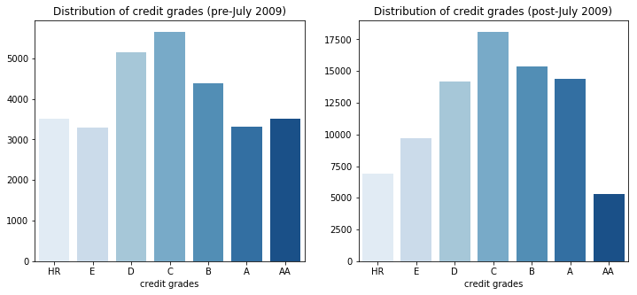

```python
plt.figure(figsize=[12,5])
plt.subplot(1,2,1)
sb.countplot(data = before, x = 'CreditGrade', palette = 'Blues')
plt.ylabel('')
plt.xlabel('credit grades')
plt.title('Distribution of credit grades (pre-July 2009)');

plt.subplot(1,2,2)
sb.countplot(data = after, x = 'ProsperRating (Alpha)', palette = 'Blues')
plt.ylabel('')
plt.xlabel('credit grades')
plt.title('Distribution of credit grades (post-July 2009)');
```

## Proportion of borrower states

Of all the loan records, there are 12.9% of the loan records came from California(CA) which is much higher than the rest of the states. The other top 5 states are Texas(TX), (Florida)FL, (New York)NY and (Illinois)IL.

```python
#  Select the states that have more than 2000 records.
states = loan_clean.BorrowerState.value_counts()[loan_clean.BorrowerState.value_counts() > 2000].index
sub_loan_clean = loan_clean[loan_clean['BorrowerState'].isin(states)]
```

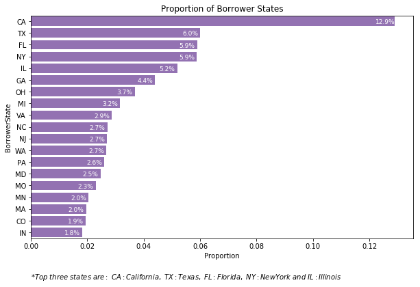

```python
base_color = sb.color_palette()[4]
base_count = sub_loan_clean.BorrowerState.value_counts()
base_order = sub_loan_clean.BorrowerState.value_counts().index

total = loan_clean.shape[0]
biggest = sub_loan_clean.BorrowerState.value_counts()[0]
big = biggest/total

tick_props = np.arange(0,big,0.02)
tick_names = ['{:0.2f}'.format(v) for v in tick_props]

plt.figure(figsize=[10,6])
sb.countplot(data = sub_loan_clean, y = 'BorrowerState', color = base_color, order = base_order)
plt.xticks(tick_props*total, tick_names)
plt.xlabel('Proportion')
locs,labels = plt.yticks()
plt.title('Proportion of Borrower States')
plt.text(0, 22, r'$*Top\ three\ states\ are:\ CA: California,\ TX: Texas,\ FL: Florida,\ NY: New York\ and\ IL: Illinois$',
         fontdict={'size': 10, 'color': 'black'});

for loc, label in zip(locs,labels):
    count = base_count[label.get_text()]
    string = '{:0.1f}%'.format(100*count/total)
    plt.text(count-400, loc+0.2, string, ha ="center", color = 'w', fontsize = 9);
```

## Distribution of Loan Original Amount

The distribution of loan amount has lots of peaks which are concentrated near 5000, 10000, 15000, 20000, 25000, 30000 and 35000. And the interesting part is every time before those peaks there is a steep-jump instead of a smooth ramp-up which means people intend to borrow(get) the integer amount of loans especially when it's a large number.

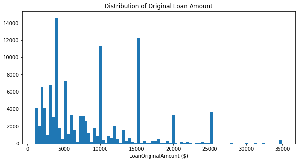

```python
plt.figure(figsize=[10,5])

binsize = 400
bins = np.arange(1000, loan_clean['LoanOriginalAmount'].max()+binsize, binsize)

plt.hist(data = loan_clean, x = 'LoanOriginalAmount', bins = bins)

plt.xlabel('LoanOriginalAmount ($)')
plt.title('Distribution of Original Loan Amount');
```

## BorrowerRate, Loan Original Amount and Simplified Loan Status by Credit Grade

Both before and after July 2009, the loan amount and result both have a positive correlation with the creditGrade, while borrower rate has a negative correlation with the creditGrade. Although basically, the correlation between ProsperRating and those three variables are the same. There are two results i found interesting:  
1.Compared to the previous time, the current Prosper Rating has a stronger impact on the borrower rates, and the average borrower rates is much smaller on level AA.  
2.Compared to the previous time, the result now is much better, the good result is around 75% even if it's the lowest Prosper Rating.

```python
# Simplified loan status by filtering the status into "Good:1" and "Bad:0".
loan_clean['Result'] = np.where(loan_clean['LoanStatus'].isin(['Chargedoff', 'Defaulted', 'Past Due (1-15 days)', 'Past Due (31-60 days)','Past Due (61-90 days)','Past Due (91-120 days)','Past Due (16-30 days)','Past Due (>120 days)']), 0, 1)
```

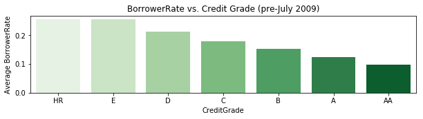

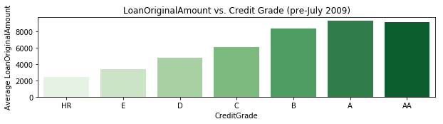

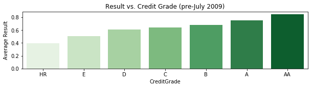

```python
sub_loan_clean = loan_clean.groupby('CreditGrade').mean().reset_index()

def CreditGrade_vs(number,factor):
    plt.figure(figsize=[10,7])
    plt.subplot(3,1,number)
    sb.barplot(data = sub_loan_clean, x = 'CreditGrade', y = factor, palette = 'Greens')
    plt.title('{} vs. Credit Grade (pre-July 2009)'.format(factor));
    plt.ylabel("Average {}".format(factor))
    return plt.show()

CreditGrade_vs(1,'BorrowerRate'),
CreditGrade_vs(2,'LoanOriginalAmount'),
CreditGrade_vs(3,'Result')
```

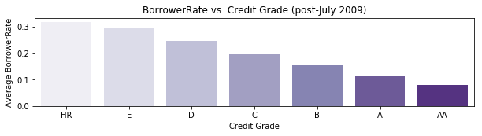

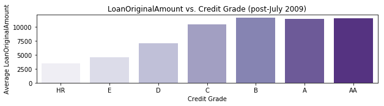

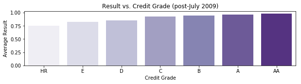

```python
sub_loan_clean1 = loan_clean.groupby('ProsperRating (Alpha)').mean().reset_index()

def CreditGrade_vs(number,factor):
    plt.figure(figsize=[10,7])
    plt.subplot(3,1,number)
    sb.barplot(data = sub_loan_clean1, x = 'ProsperRating (Alpha)', y = factor, palette = 'Purples')
    plt.xlabel('Credit Grade')
    plt.ylabel("Average {}".format(factor))
    plt.title('{} vs. Credit Grade (post-July 2009)'.format(factor));
    return plt.show()

CreditGrade_vs(1,'BorrowerRate'),
CreditGrade_vs(2,'LoanOriginalAmount'),
CreditGrade_vs(3,'Result');
```

## Borrower Rate vs. Credit Grade

As we was expected, the borrower rate decreases as Prosper rating increases and it's interesting to see that many things changed with time passing by. Compared with pre-July 2009 :

1. The borrower rate range for each Prosper rating has been more accurate. On the other hand, the division of borrower rates between different ratings is clearer and the difference is bigger, indicating that the classification is more strict and more complete.
2. The current Prosper Rating has a stronger impact on the borrower rate, and the average borrower rate is much smaller on level AA.

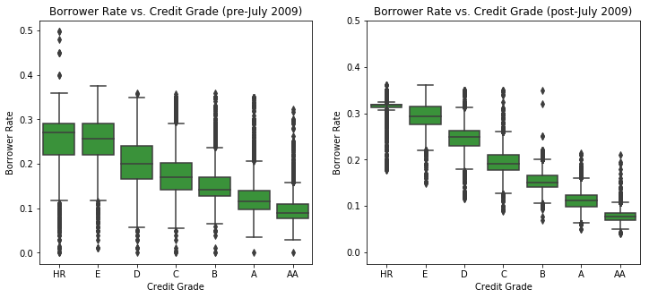

```python
plt.figure(figsize=[12,5])
plt.subplot(1,2,1)
base_color = sb.color_palette()[2]
sb.boxplot(data = loan_clean, x = 'CreditGrade', y = 'BorrowerRate', color = base_color);
plt.xlabel('Credit Grade')
plt.ylabel('Borrower Rate');
plt.title('Borrower Rate vs. Credit Grade (pre-July 2009)')

plt.subplot(1,2,2)
base_color = sb.color_palette()[2]
sb.boxplot(data = loan_clean, x = 'ProsperRating (Alpha)', y = 'BorrowerRate', color = base_color)
plt.xlabel('Credit Grade')
plt.ylabel('Borrower Rate')
plt.title('Borrower Rate vs. Credit Grade (post-July 2009)')
plt.ylim(-0.025,0.5);
```

## Loan Original Amount and Borrower Rate by Credit Grade

Time plays a very crucial roles in the relationship between borrower rate, loan amount and credit rating. It is very interesting that nowadays credit rating actually plays a very important role in our life. With a high standard credit evaluation system, you can borrow a lot of money with a very low borrowing rate. The original dataset has more than 80 variables, although in this project I mainly focused on how credit rating influence the loan, maybe later we can explore how credit rating is affected by other factors.

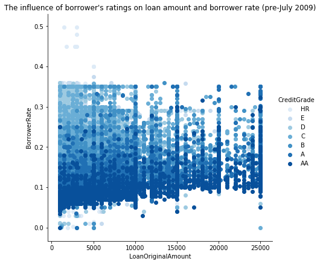

```python
g = sb.FacetGrid(data = loan_clean, hue = 'CreditGrade', palette = 'Blues', size = 6)
g.map(plt.scatter, 'LoanOriginalAmount', 'BorrowerRate')
plt.title("The influence of borrower's ratings on loan amount and borrower rate (pre-July 2009)")
g.add_legend();
```

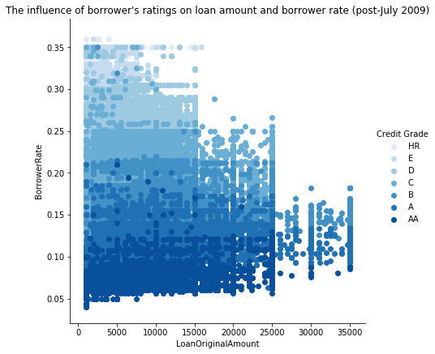

```python
data = loan_clean.rename(columns={'ProsperRating (Alpha)': 'Credit Grade'})
g = sb.FacetGrid(data = data, hue = 'Credit Grade', palette = 'Blues', size = 6)
g.map(plt.scatter, 'LoanOriginalAmount', 'BorrowerRate')
plt.title("The influence of borrower's ratings on loan amount and borrower rate (post-July 2009)")
g.add_legend();
```